FJ

# Feidhelm Joyce

Business & Data Analyst  
Boston, MA

linkedin.com/in/feidhelmjoyce  
github.com/FeidhelmJ

DATA MINING FOR BUSINESS ANALYTICS

## Text Mining & Sentiment Analysis

← Back to Data Mining for Business Analytics

```
import numpy as np
import pandas as pd
import matplotlib.pyplot as plt
import seaborn as sns
```

Load the Office dataset into your Python environment. Choose a season.

```
office = pd.read_csv('office.csv')
```

```
office.head()
```

|  | id | season | episode | scene | line_text | speaker | deleted |
| --- | --- | --- | --- | --- | --- | --- | --- |
| 0 | 1 | 1 | 1 | 1 | All right Jim. Your quarterlies look very good... | Michael | False |
| 1 | 2 | 1 | 1 | 1 | Oh, I told you. I couldn't close it. So... | Jim | False |
| 2 | 3 | 1 | 1 | 1 | So you've come to the master for guidance? Is ... | Michael | False |
| 3 | 4 | 1 | 1 | 1 | Actually, you called me in here, but yeah. | Jim | False |
| 4 | 5 | 1 | 1 | 1 | All right. Well, let me show you how it's done. | Michael | False |

Filter the dataset so that it only contains your season.

```
office_new = office[office['season'] == 5]
```

```
office_new.head()
```

|  | id | season | episode | scene | line_text | speaker | deleted |
| --- | --- | --- | --- | --- | --- | --- | --- |
| 22613 | 22614 | 5 | 1 | 1 | All right, everybody. This is your last meal, ... | Michael | False |
| 22614 | 22615 | 5 | 1 | 1 | From this point forward, you will not use the ... | Dwight | False |
| 22615 | 22616 | 5 | 1 | 2 | This summer, corporate is sponsoring a little ... | Michael | False |
| 22616 | 22617 | 5 | 1 | 3 | What should we do with all these leftovers? | Meredith | False |
| 22617 | 22618 | 5 | 1 | 3 | I'm taking the dumplings for my wife. | Stanley | False |

Who are the ten characters (or entities) that had the most lines in your season? Create a barplot that depicts the count values for each of these top 10. Orient this barplot horizontally, and be sure to order your bars, either from highest to lowest or lowest to highest. (If there are lines delivered by multiple characters, they could count as their own group, or entity) In a couple of sentences, what insights could be drawn from this plot

- The barplot shows that Michael delivers the highest number of lines by a large margin, followed by Dwight, Jim, and Pam. This suggests that the season’s narrative centers heavily around the core characters, with secondary characters such as Angela, Oscar, and Kevin contributing far fewer lines. The strong drop-off after the top few characters indicates that the dialogue distribution is highly uneven, reinforcing the show’s focus on a small group of central personalities.

```
duplicate_lines_exist = office_new['line_text'].duplicated().any()
print(f"Are there any duplicate lines in the 'office_new' DataFrame? {duplicate_lines_exist}")
```

```
Are there any duplicate lines in the 'office_new' DataFrame? True
```

```
multi_mask = office_new["speaker"].str.contains("&|,|/| and ", case=False, na=False)
```

```
multi_lines = office_new[multi_mask]
```

```
multi_speaker_counts = (
    office_new[multi_mask]
    .groupby("speaker")
    .size()
    .sort_values(ascending=False)
)

print(multi_speaker_counts.head(10))
```

```
speaker
Michael & Holly                 4
Jim, Pam, Michael and Dwight    2
Angela and Kelly                1
Dwight and Michael              1
Holly & Darryl                  1
Dwight and Andy                 1
Dwight and Erin                 1
Jim and Pam                     1
Holly & Michael                 1
Kevin & Andy                    1
dtype: int64
```

```
speaker_counts = office_new['speaker'].value_counts().head(10)
speaker_counts
```

| speaker | count |
| --- | --- |
| Michael | 2163 |
| Dwight | 1075 |
| Jim | 875 |
| Pam | 706 |
| Andy | 497 |
| Holly | 270 |
| Angela | 221 |
| Charles | 221 |
| Oscar | 216 |
| Kevin | 187 |

```
sns.countplot(y = 'speaker', data = office_new, order = speaker_counts.index, color = 'blue')
plt.ylabel('Speaker')
plt.xlabel('Count')
plt.title('Top 10 Characters by Line Count')
plt.show()
```

[figure not shown]

Generate a new dataframe for your season that only contains the line_text column from your season. Convert your text into a dataframe in which each word occupies its own row.

```
office_lines = office_new[['line_text']].copy()
```

```
office_lines["word"] = office_lines["line_text"].str.split()
```

```
words_df = office_lines.explode("word")
```

```
words_df.head()
```

|  | line_text | word |
| --- | --- | --- |
| 22613 | All right, everybody. This is your last meal, ... | All |
| 22613 | All right, everybody. This is your last meal, ... | right, |
| 22613 | All right, everybody. This is your last meal, ... | everybody. |
| 22613 | All right, everybody. This is your last meal, ... | This |
| 22613 | All right, everybody. This is your last meal, ... | is |

What were the 10 most frequently used words in your season? Show the code that you used to answer this question, along with your results.

Why is this list of very limited value for any kind of analysis? Now, remove the stopwords. Show the code that you used to do this. With the stopwords removed, what are the 10 most common words in your episode? Show them here.

- Stopwords, in dialogue don't really show or tell us anything about the tone or mood in a scene. It is impossible to get any insight into a scene or season simply by analyzing these 'filler' words.

Do this again, but instead, do it with bigrams instead of unigrams. How are bigrams different from unigrams?

- Bigrams, on the other hand, are pairs of consecutive words (e.g., "michael scott", "come on", "no no"). Bigrams reveal meaningful phrases, character names, repeated jokes, and patterns of dialogue that unigrams cannot capture.

How might bigram analysis yield different results than unigram analysis, in general? Write 1-2 sentences that speculate about why it might be useful/interesting to see this list of the most frequently-used words from your season (you could mention the bigrams or the unigrams here). What could someone do with it? Use your imagination and creativity to answer this and be sure to reference your specific words from your season.

- Bigram analysis captures meaningful two-word phrases—such as character names, catchphrases, or repeated conversational patterns—that unigrams miss, which makes it possible to see how characters interact or what themes dominate the season. Seeing the most frequent unigrams or bigrams in my season could highlight recurring phrases like “you know,” or “going to,” helping someone analyze character dynamics, identify signature lines, or even build a predictive text generator that mimics the dialogue style of the show.

```
word_count = words_df['word'].value_counts().head(10)
word_count
```

| word | count |
| --- | --- |
| I | 3025 |
| to | 2211 |
| the | 2098 |
| you | 1952 |
| a | 1909 |
| and | 1099 |
| is | 1018 |
| of | 921 |
| that | 794 |
| in | 792 |

```
import nltk
nltk.download('stopwords')

from nltk.corpus import stopwords
stop_words = set(stopwords.words('english'))
```

```
[nltk_data] Downloading package stopwords to /root/nltk_data...
[nltk_data]   Unzipping corpora/stopwords.zip.
```

```
words_df["clean_word"] = (
    words_df["word"]
    .str.lower()
    .str.replace(r"[^a-z']", "", regex=True))
words_df = words_df[words_df["clean_word"] != ""]
```

```
words_nostop = words_df[~words_df["clean_word"].isin(stop_words)]
```

```
words_nostop_count = words_nostop['clean_word'].value_counts().head(10)
words_nostop_count
```

| clean_word | count |
| --- | --- |
| oh | 570 |
| know | 524 |
| michael | 505 |
| yeah | 413 |
| okay | 388 |
| like | 377 |
| get | 367 |
| right | 350 |
| going | 316 |
| hey | 311 |

```
from nltk import bigrams
```

```
words_list = words_df["clean_word"].tolist()
bigram_list = list(bigrams(words_list))
```

```
bigram_df = pd.DataFrame(bigram_list, columns=["word1", "word2"])
```

```
bigram_df["bigram"] = bigram_df["word1"] + " " + bigram_df["word2"]

top10_bigrams = bigram_df["bigram"].value_counts().head(10)
top10_bigrams
```

| bigram | count |
| --- | --- |
| you know | 225 |
| i don't | 224 |
| going to | 217 |
| and i | 215 |
| no no | 209 |
| in the | 202 |
| i am | 194 |
| are you | 193 |
| this is | 191 |
| i have | 186 |

Generate a word cloud based on your season. What does your word cloud show you? Describe it in a sentence or two

```
from wordcloud import WordCloud
```

```
text = " ".join(words_nostop["clean_word"].tolist())

wc = WordCloud(
    width=800,
    height=400,
    background_color="white",
    colormap="viridis"
).generate(text)

plt.figure(figsize=(12, 6))
plt.imshow(wc, interpolation='bilinear')
plt.axis("off")
plt.title("Word Cloud for Season 5 (Stopwords Removed)", fontsize=16)
plt.show()
```

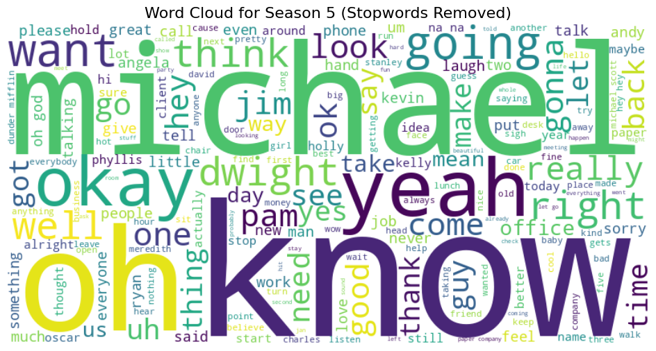

The word cloud highlights the most frequently used meaningful words in Season 5, with terms like “michael,” “know,” “yeah,” “okay,” “want,” and “going” appearing the largest, showing they dominate the dialogue. This visualization reveals both the characters who speak the most (Michael, Jim, Dwight, Pam) and the conversational tone of the season, which is filled with casual, expressive words like “oh,” “hey,” “right,” and “gonna,” reflecting the show’s informal, comedic style.

Next, let’s do some sentiment analysis. What 10 words made the biggest sentiment contributions in your season? Show the code that you used to find this, along with your results. Of these top 10 words, how many were positive? How many were negative? In a sentence or two, speculate about what this list suggests about your season.

- Looking at the sentiment analysis for season 5, all of the words in top 10 sentiment contribution list were positive, with words like 'good', 'great', and 'love' scoring scoring highest on sentiment score. This highlights the fun, easy-going nature of the show, words like 'ok', and 'well' could maybe be interpreted as negative depending on the context, further investigation may be required.

```
!pip install vaderSentiment
from vaderSentiment.vaderSentiment import SentimentIntensityAnalyzer

analyzer = SentimentIntensityAnalyzer()
```

[output not shown]

```
word_freq = words_nostop["clean_word"].value_counts()
sentiment_scores = []

for word, count in word_freq.items():
    score = analyzer.polarity_scores(word)["compound"]
    contribution = score * count
    sentiment_scores.append((word, score, count, contribution))
```

```
sentiment_df = pd.DataFrame(sentiment_scores, columns=[
    "word", "sentiment_score", "frequency", "sentiment_contribution"])

top10_sentiment = sentiment_df.sort_values("sentiment_contribution", key=abs, ascending=False).head(10)

top10_sentiment
```

|  | word | sentiment_score | frequency | sentiment_contribution |
| --- | --- | --- | --- | --- |
| 5 | like | 0.3612 | 377 | 136.1724 |
| 12 | good | 0.4404 | 296 | 130.3584 |
| 3 | yeah | 0.2960 | 413 | 122.2480 |
| 4 | okay | 0.2263 | 388 | 87.8044 |
| 42 | great | 0.6249 | 127 | 79.3623 |
| 27 | yes | 0.4019 | 194 | 77.9686 |
| 14 | well | 0.2732 | 285 | 77.8620 |
| 24 | ok | 0.2960 | 212 | 62.7520 |
| 67 | love | 0.6369 | 94 | 59.8686 |
| 47 | thank | 0.3612 | 121 | 43.7052 |

```
positive_count = (top10_sentiment["sentiment_score"] > 0).sum()
negative_count = (top10_sentiment["sentiment_score"] < 0).sum()

positive_count, negative_count
```

```
(np.int64(10), np.int64(0))
```

**Topic: Transformers**

Instantiate a text-classification pipeline to detect emotions.

Apply this pipeline to the lines in your season and store the top-scoring emotion for each line.

What are the top 5 most frequent emotions detected? Show the code and your results (the list of emotions and their counts).

In a sentence or two, compare the results from the emotion analysis to the results from the simpler sentiment analysis. What new insights does the emotion classification give you about the season?

- The sentiment analysis showed that the strongest contributors were overwhelmingly positive, with words like “like,” “good,” “yeah,” “okay,” “great,” and “love” dominating the season’s overall tone. However, the emotion classification adds analysis that simple positivity/negativity cannot capture, despite the strong positive sentiment, the most common emotion is neutral, followed by curiosity, approval, and admiration, which highlights my point earlier that a lot of the language used is open to interpretation.

```
!pip install transformers torch --quiet

from transformers import pipeline

emotion_classifier = pipeline(
    "text-classification",
    model="SamLowe/roberta-base-go_emotions",
    return_all_scores=False)
```

[output not shown]

[output not shown]

```
emotion_labels = office_new["line_text"].apply(lambda x: emotion_classifier(x)[0]["label"])

office_new["emotion"] = emotion_labels
```

[output not shown]

```
emotion_counts = office_new["emotion"].value_counts().head(5)
emotion_counts
```

| emotion | count |
| --- | --- |
| neutral | 4282 |
| curiosity | 805 |
| approval | 593 |
| admiration | 412 |
| disapproval | 389 |